# Generalized Dissimilarity Modelling (GDM)

Author

Juliette Archambeau

Published

March 29, 2023

# 1 Introduction

Resources on *Generalized Dissimilarity Modelling* (GDM):

- Papers: Ferrier et al. (2007), Mokany et al. (2022) and Fitzpatrick and Keller (2015).
- GDM website: https://mfitzpatrick.al.umces.edu/gdm/
- GDM Github: https://github.com/fitzLab-AL/gdm

From the GDM website: ‘The R package `gdm` implements *Generalized Dissimilarity Modeling* (Ferrier et al. 2007) to analyze and map spatial patterns of biodiversity. GDM models biological variation as a function of environment and geography using **distance matrices** – specifically by relating biological dissimilarity between sites to how much sites differ in their environmental conditions (environmental distance) and how isolated they are from one another (geographical distance). […] GDM also can be used to model other biological levels of organization, notably genetic (Fitzpatrick and Keller 2015) [..] and the approaches for doing so are largely identical to the species-level case with the exception of using a different biological dissimilarity metric depending on the type of response variable.’

# 2 Formatting data

## 2.1 Genomic data

### 2.1.1 Pairwise $F_{ST}$ matrices

The GDM analysis takes as inputs matrices of pairwise $F_{ST}$.

To estimate the pairwise $F_{ST}$, we use the **individual-level** (i.e. allele counts for each genotype) **genomic data with missing data** (i.e. no imputation of the missing data), and without minor allele frequencies.

We use the **Weir and Cockerham method**, with the function `pairwise.WCfst` of the `hierfstat` package. We could have used the function `gene.dist` (with the option `WC84`), as in Gougherty, Keller, and Fitzpatrick (2021) (and the preprint [Gougherty et al. 2020](https://www.biorxiv.org/content/10.1101/2020.02.28.961060v1.abstract)). `gene.dist` keeps only the lower triangle of the $F_{ST}$ matrix, while `pairwise.WCfst` keeps the whole matrix.

```r
# we load the allele counts of each genotype
geno <- read.csv(here("data/DryadRepo/FormattedFilteredGenomicData_AlleleCounts_withoutmaf.csv"), row.names = 1)

geno[geno ==1] <- 12
geno[geno ==2] <- 22
geno[geno ==0] <- 11

geno <- geno %>%
  t() %>%
  as.data.frame() %>%
  dplyr::mutate(pop=substr(row.names(.), 0, 3)) %>%
  dplyr::select(pop, everything())

geno[1:10,1:10] %>% kable_mydf(boldfirstcolumn = T)
```

|  | pop | snp_2 | snp_3 | snp_4 | snp_5 | snp_6 | snp_7 | snp_8 | snp_9 | snp_10 |
| --- | --- | --- | --- | --- | --- | --- | --- | --- | --- | --- |
| ALT10 | ALT | 11 | 11 | 11 | 11 | 11 | 11 | 11 | 11 | 11 |
| ALT2 | ALT | 11 | 11 | 11 | 11 | 11 | 12 | 11 | 11 | 11 |
| ALT3 | ALT | 11 | 11 | 11 | 11 | 11 | 11 | 12 | 11 | 11 |
| ALT4 | ALT | 11 | 11 | 12 | 11 | 11 | 12 | 11 | 11 | 11 |
| ALT5 | ALT | 11 | 11 | 11 | 11 | 11 | 11 | 11 | 11 | 11 |
| ALT6 | ALT | 12 | 11 | 12 | 11 | 11 | 11 | 11 | 11 | 11 |
| ALT8 | ALT | 11 | 11 | 11 | 11 | 11 | 12 | 11 | 11 | 11 |
| ALT9 | ALT | 11 | 11 | 11 | 11 | 11 | 11 | 11 | 11 | 11 |
| ARM1 | ARM | 11 | 11 | 11 | 11 | 11 | 11 | 11 | 12 | 11 |
| ARM10 | ARM | 11 | 12 | 11 | 11 | 11 | 11 | 11 | 11 | 11 |

We load the sets of candidate and control SNPs.

```r
snp_sets <- readRDS(here("outputs/list_snp_sets.rds"))
```

We calculate the pariwise $F_{ST}$ matrices.

```r
fst_matrices <- sapply(snp_sets, function(x){

geno %>%
  dplyr::select(pop,all_of(x$set_snps)) %>%
  pairwise.WCfst(diploid=TRUE)

}, USE.NAMES = TRUE,simplify=FALSE)

# save it
saveRDS(fst_matrices,file=here("data/GDManalysis/FstMatrices.rds"))
```

### 2.1.2 Negative values

```r
neg_vals <- sapply(fst_matrices, function(x){ length(x[which(x <0)])}, USE.NAMES = TRUE,simplify=FALSE)
```

It generally means there is more variation within than among populations and is likely to result from uneven sample sizes.

### 2.1.3 Scaling the $F_{ST}$ matrices

We have to scale the $F_{ST}$ matrices between 0 and 1 to facilitate model convergence and to enable comparisons the different sets of SNPs, which display different ranges of observed $F_{ST}$ values.

We standardize the $F_{ST}$ values in the following way:

$$x_{new} = \frac{x- x_{min}}{x_{max}-x_{min}}$$

This was proposed here: https://www.statisticshowto.com/probability-and-statistics/normal-distributions/normalized-data-normalization/

```r
fst_matrices <- sapply(fst_matrices, function(x){

 (x-min(x,na.rm=T))/(max(x,na.rm=T)-min(x,na.rm=T))

}, USE.NAMES = TRUE,simplify=FALSE)


# To check that it worked
# sapply(fst_matrices, function(x){range(x,na.rm=T)}, USE.NAMES = TRUE,simplify=FALSE)
```

### 2.1.4 Matrix visualization

```r
source(here("scripts/functions/corpmat.R"))
col <- colorRampPalette(c("#BB4444", "#EE9988", "#FFFFFF", "#77AADD", "#4477AA"))

viz_matrix <- function(x,plot_title) {

  p.mat <- corpmat(x)

  p <- corrplot::corrplot(x, method="color", col=col(200),
                   type="upper", order="hclust",
                   addCoef.col = "black", # Add coefficient of correlation
                   tl.col="black", tl.srt=23, #Text label color and rotation
                   # Combine with significance
                   p.mat = p.mat, sig.level = 0.05, insig = "blank", number.cex =0.8,tl.cex = 0.8,
                   # hide correlation coefficient on the principal diagonal
                   diag=FALSE,
                   title = plot_title,mar=c(0,0,2,0)) # add an upper margin to see the title

  return(p)
}
```

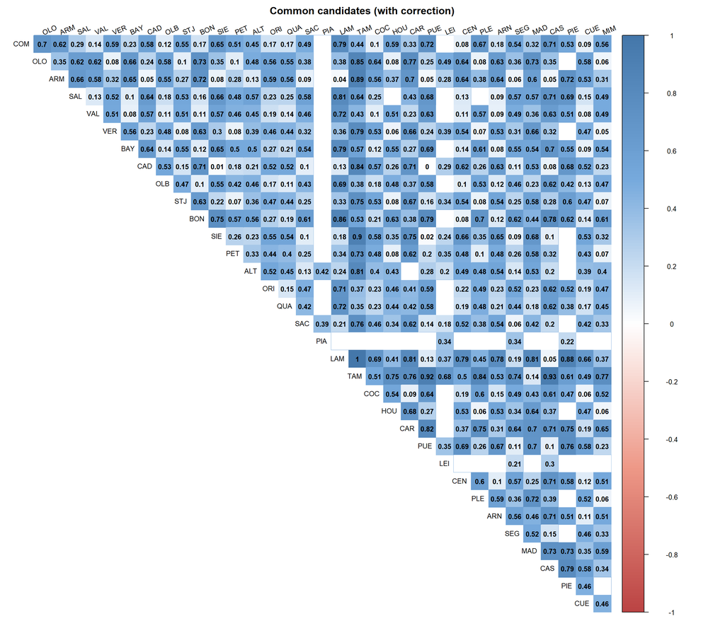

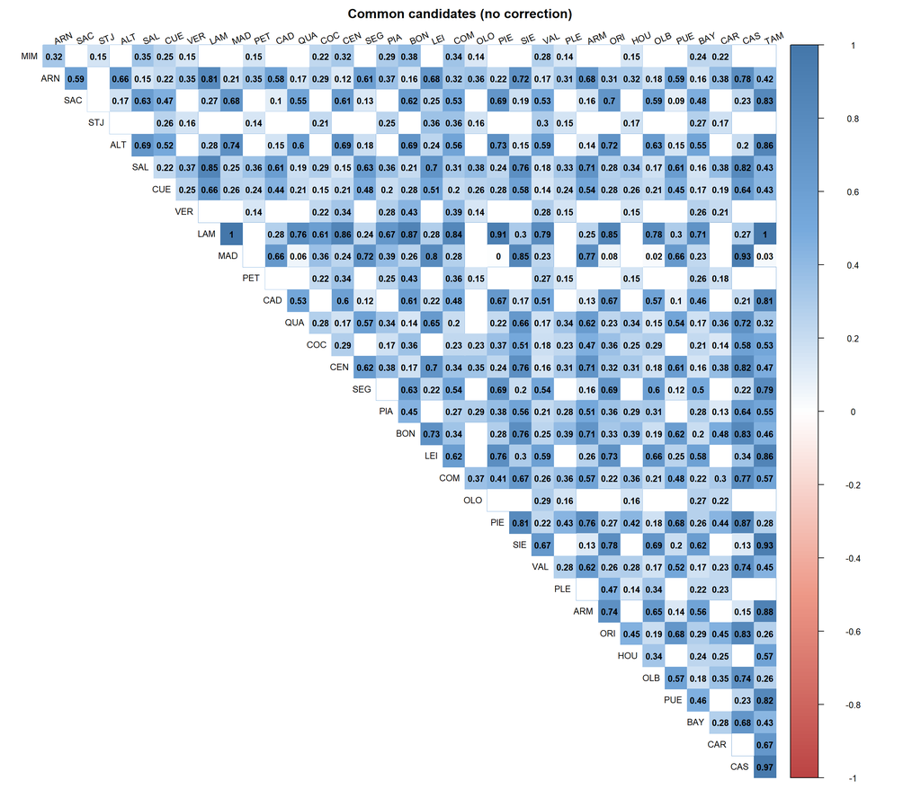

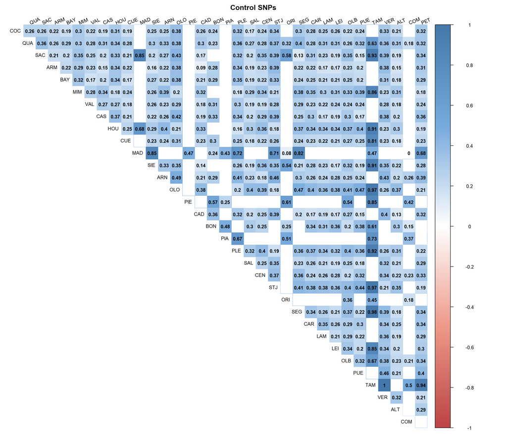

```r
lapply(1:3, function(x) viz_matrix(x=fst_matrices[[x]],
                                   plot_title = snp_sets[[x]]$set_name))
```

### 2.1.5 Matrix formatting for GDM

For the `gdm` package: the distance matrix must have as the first column the names of the populations.

```r
fst_matrices <- sapply(fst_matrices, function(x){

x <- x %>%
    as.data.frame() %>%
    tibble::rownames_to_column("pop")

}, USE.NAMES = TRUE,simplify=FALSE)


saveRDS(fst_matrices,file=here("data/GDManalysis/ScaledFstMatrices.rds"))
```

## 2.2 Climatic data

We do not have to scale the climatic data before the GDM analysis, as **scaling of predictors is part of model fitting in GDM**, as said in Mokany et al. (2022): ‘As different predictors are measured on different scales (e.g., temperature in degrees, precipitation in mm), they are transformed as part of model fitting, such that the transformed distance between a pair of sites for different predictors can be meaningfully compared and combined.’

```r
# Selected climatic variables
# ===========================
clim_var <- readRDS(here("data/ClimaticData/NamesSelectedVariables.rds")) %>%
  `[[`(3) # We keep the set 3 of climatic variables (the third list element)


# Past and future climatic data with dbMEMs
# =========================================
clim_past <- read_csv(here("data/DryadRepo/PopulationCoordinatesPastClimateInformation.csv"),
                        show_col_types = FALSE) %>%
  dplyr::select(pop,contains("ude"),clim_var$variables) # we keep only the climatic variables of interest and the dbMEMs

clim_fut <- read_csv(here("data/DryadRepo/PopulationCoordinatesFutureClimateInformation.csv"),
                       show_col_types = FALSE) %>%
  dplyr::select(pop,clim_var$variables)
```

Selected climatic variables:

```r
extract_climatedt_metadata(var_clim = clim_var$variables) %>%
  dplyr::select(label,description,unit) %>%
  set_colnames(str_to_title(colnames(.))) %>%
  kable_mydf(font_size = 12)
```

| Label | Description | Unit |
| --- | --- | --- |
| bio1 | Mean annual temperature | Celsius degrees (°C) |
| bio3 | Isothermality (bio2/bio7) (×100) | index |
| bio9 | Mean temperature of driest quarter | Celsius degrees (°C) |
| Eref | Hargreaves reference evaporation | mm / day |
| AHM | Annual heat moisture index | °C / mm |
| SHM | Summer heat moisture index | °C / mm |

# 3 GDM fitting

> Combining genomic and climatic data with `formatsitepair`

We use the `formatsitepair` function to combine the genomic and climatic data into ‘population-pair’ table format. In our case, we use a **pairwise biological dissimilarity matrix** (i.e. pairwise $F_{ST}$) as response variable, and therefore we have to set `bioFormat=3` in the `formatsitepair` function.

**Warning!** The rows and columns of the distance matrix have to be in the same order as the rows of the climatic variables. And the distance matrix and the climatic data must not include NAs.

**Warning!** Note that the `formatsitepair` function assumes that the coordinates of the sites are in the same coordinate system as the rasters. At present, no checking is performed to ensure this is the case. Note also that if your site coordinates are longitude-latitude that the **calculation of geographic distances between sites will have errors**, the size of which will depend on the geographic extent and location of your study region. We hope to deal with this in a later release, but **for now you can avoid these problems by using a projected coordinate system (e.g., equidistant)**.

> GDM fitting

From the GDM website: ’GDM is a nonlinear extension of permutational matrix regression that uses flexible splines and generalized linear modeling (GLM) to accommodate two types of nonlinearity common in ecological datasets: (1) variation in the rate of compositional turnover (non-stationarity) along environmental gradients, and (2) the curvilinear relationship between biological distance and environmental and geographical distance.

Generalized dissimilarity models are fitted with the `gdm` function.

From the GDM website: ‘Even though these option are available, using the default values for these parameters will work fine for most applications. In other words, unless you have a good reason, you should probably use the default settings for splines and knots. The effects (and significance) of altering the number of splines and knot locations has not been systematically explored.’

```r
snp_sets <- lapply(snp_sets, function(x){

x$gdm_tab <- gdm_tab <- formatsitepair(bioData=fst_matrices[[x$set_code]],
                                       bioFormat=3,
                                       XColumn="longitude",
                                       YColumn="latitude",
                                       predData=clim_past,
                                       siteColumn="pop")



x$gdm_mod <- gdm_mod  <- gdm(data=gdm_tab, geo=TRUE)

return(x)

})
```

# 4 GDM plots

> Observed genetic distance vs predicted climatic distance

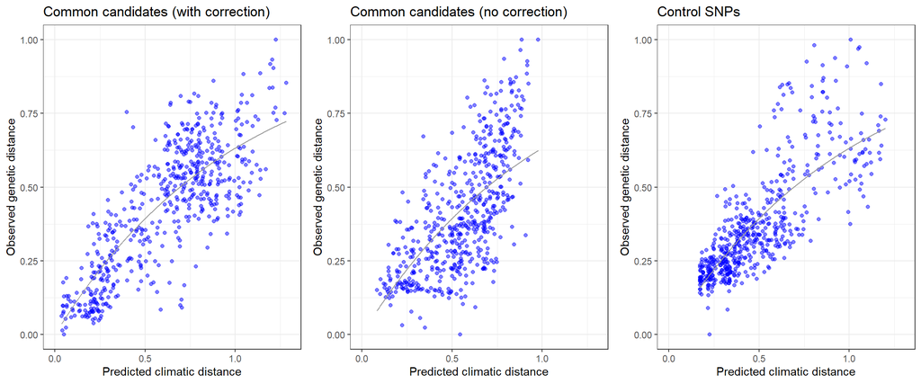

```r
# Plot predicted climatic distance vs observed genetic distance

plots <- lapply(snp_sets, function(x){

overlay_x <- seq( from=min(x$gdm_mod$ecological), to=max(x$gdm_mod$ecological), length=length(x$gdm_mod$ecological) )
overlay_y <- 1 - exp( - overlay_x )
dfline <- tibble(x=overlay_x,y=overlay_y)

tibble(clim=x$gdm_mod$ecological,
       obs=x$gdm_mod$observed) %>%
  ggplot(aes(x=clim,y=obs)) +
  geom_point(color=rgb(0,0,1,0.5)) +
  geom_line(data=dfline,aes(x=x,y=y), color="gray60") +
  xlim(c(0,1.3)) +
  ylim(c(0,1)) +
  xlab("Predicted climatic distance") +
  ylab("Observed genetic distance") +
  ggtitle(x$set_name) +
  theme_bw()

})

plot_grid(plotlist=plots, nrow=1)
```

> Predicted versus observed genetic distance

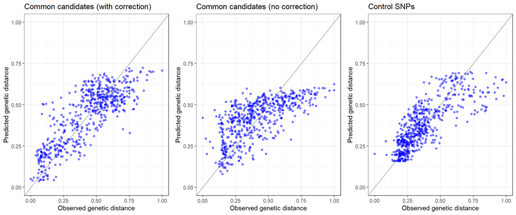

```r
plots <- lapply(snp_sets, function(x){

tibble(obs=x$gdm_mod$observed, # can also be extracted with x$gdm_tab$distance
       pred=x$gdm_mod$predicted) %>%
  ggplot(aes(x=obs,y=pred)) +
  geom_abline(intercept = 0, slope = 1, color="gray60") +
  geom_point(color=rgb(0,0,1,0.5)) +
  xlim(c(0,1)) + ylim(c(0,1)) +
  xlab("Observed genetic distance") +
  ylab("Predicted genetic distance") +
  ggtitle(x$set_name) +
  theme_bw()

})

plot_grid(plotlist=plots, nrow=1)
```

> I-splines

From the GDM website: ‘The **fitted splines** represent one of the most informative components of a fitted GDM and so plotting and scrutinizing the splines is a major part of interpreting GDM and the analyzed biological patterns.’

I-splines are shown for predictors with non-zero coefficients, i.e. predictors with a relationship with the genetic distance.

**I-spline interpretation:** (from the GDM website) ’The **maximum height of each spline** indicates the **magnitude of total genetic change** along that gradient and thereby corresponds to the **relative importance** of that predictor in contributing to allelic turnover while holding all other variables constant (i.e., is a partial climatic distance). The **spline’s shape** indicates how the **rate of genetic change** varies with position along that gradient. Thus, the splines provide insight into the total magnitude of genetic change as a function of each gradient and where along each gradient those changes are most pronounced.

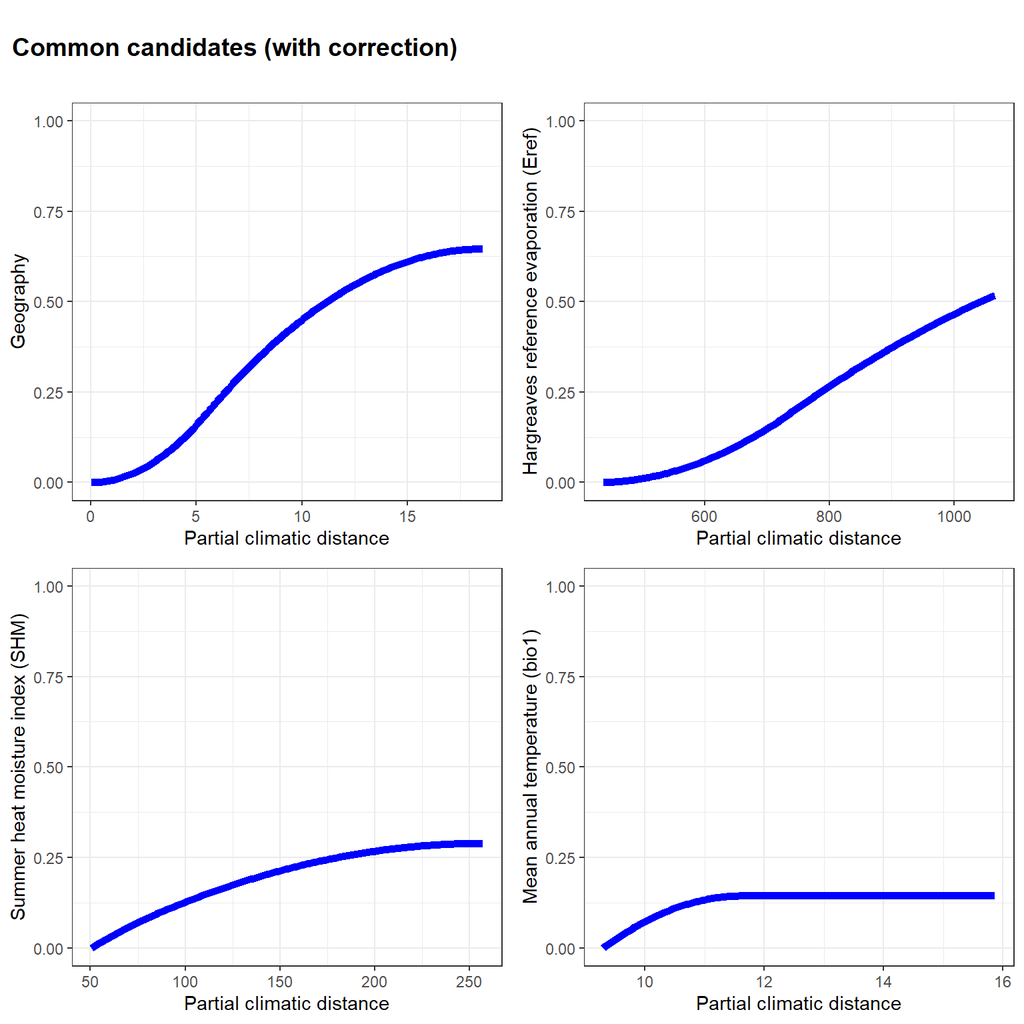

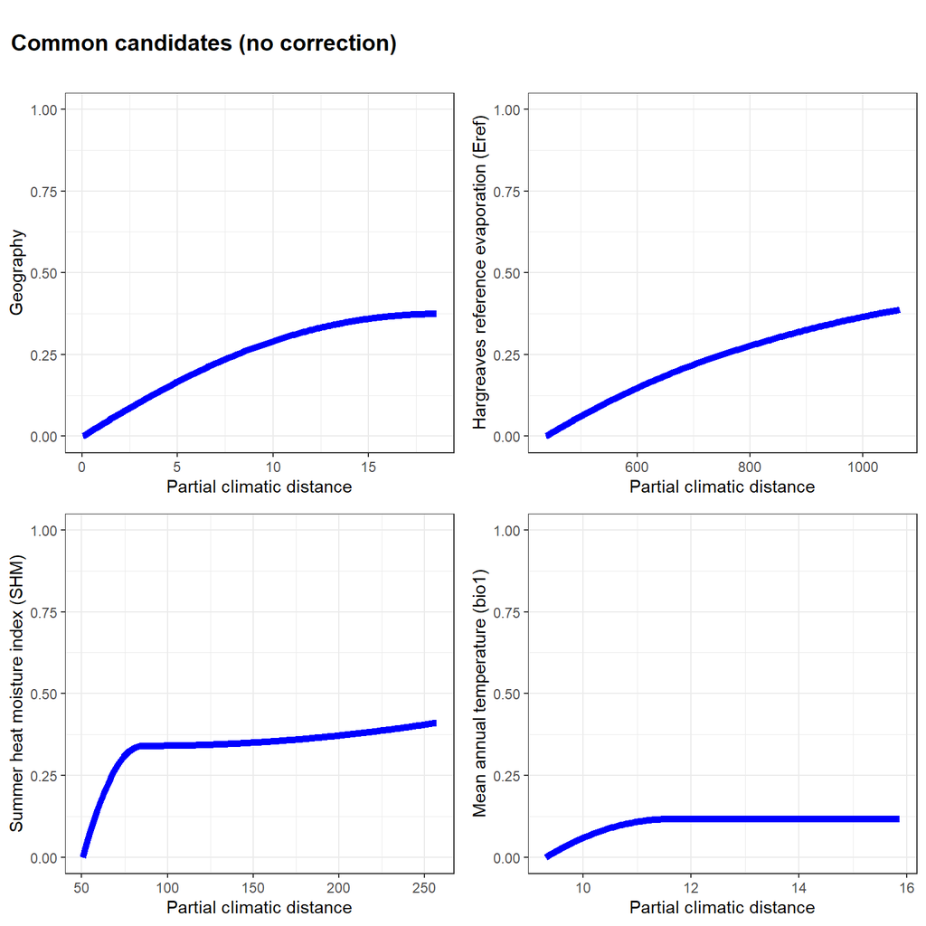

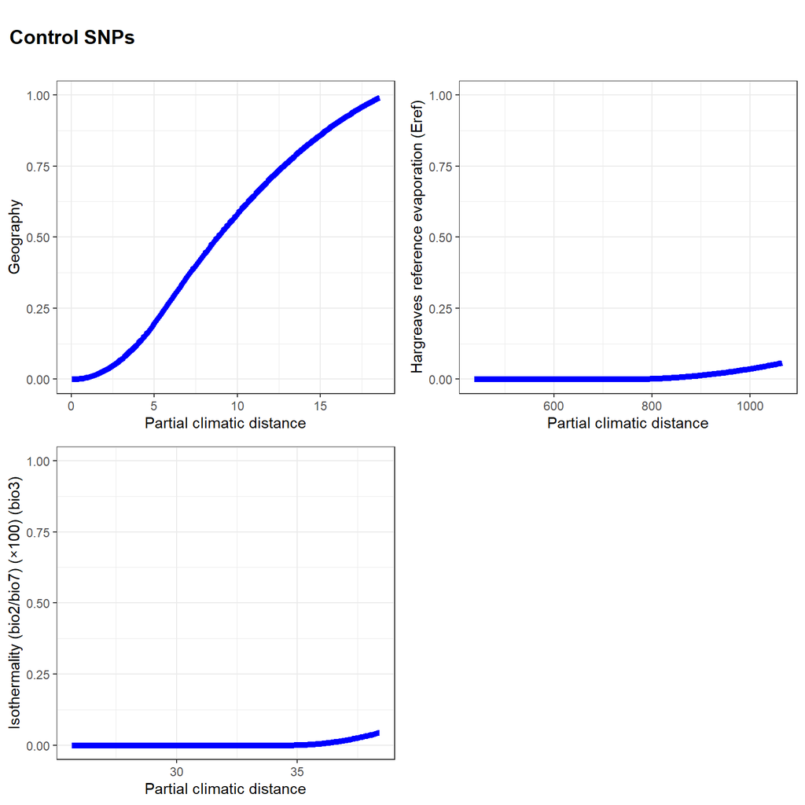

```r
lapply(snp_sets, function(x){

spline_data <- isplineExtract(x$gdm_mod)

# extract variables with importance different from 0
predictors <- which(apply(spline_data$y,2, sum) != 0) %>% names()

plots <- lapply(predictors, function(predictor){

if(predictor=="Geographic"){
  predictor_name <- "Geography"
}  else {
predictor_name <- extract_climatedt_metadata(var_clim = clim_var$variables) %>%
  dplyr::select(label,description,unit) %>%
  filter(label %in% predictor) %>%
  pull(description)
predictor_name <- paste0(predictor_name," (",predictor,")")
}

tibble(x=spline_data$x[,predictor],
       y=spline_data$y[,predictor]) %>%
  ggplot() +
  geom_line(aes(x=x,y=y),color="blue",linewidth=2) +
  ylim(c(0,1)) +
  xlab("Partial climatic distance") +
  ylab(predictor_name) +
  theme_bw()

})

# make title
title <- ggdraw() +
  draw_label(x$set_name,
             fontface = 'bold',
             x = 0,
             hjust = 0) +
  theme(plot.margin = margin(0, 0, 0, 7))

# merge plots
p <- plot_grid(plotlist=plots)

# merge plots + title
plot_grid(title, p, ncol = 1,rel_heights = c(0.1, 1)
)
})
```

## References

Ferrier, Simon, Glenn Manion, Jane Elith, and Karen Richardson. 2007. “Using Generalized Dissimilarity Modelling to Analyse and Predict Patterns of Beta Diversity in Regional Biodiversity Assessment.” *Diversity and Distributions* 13 (3): 252–64.

Fitzpatrick, Matthew C, and Stephen R Keller. 2015. “Ecological Genomics Meets Community-Level Modelling of Biodiversity: Mapping the Genomic Landscape of Current and Future Environmental Adaptation.” *Ecology Letters* 18 (1): 1–16.

Gougherty, Andrew V, Stephen R Keller, and Matthew C Fitzpatrick. 2021. “Maladaptation, Migration and Extirpation Fuel Climate Change Risk in a Forest Tree Species.” *Nature Climate Change* 11 (2): 166–71.

Mokany, Karel, Chris Ware, Skipton NC Woolley, Simon Ferrier, and Matthew C Fitzpatrick. 2022. “A Working Guide to Harnessing Generalized Dissimilarity Modelling for Biodiversity Analysis and Conservation Assessment.” *Global Ecology and Biogeography* 31 (4): 802–21.